# Assignment 2

Aliza

11/4/2018

## Question 1

1. The model : houseval ~ transit * railtype + density + I(density^2)
- houseval is the dependent variable. This is the value we hope to predict using the other variables.
- transit, railtype, and density are independent variables
- density ^ 2 is a quadratic form of an independent variable. This quadratic term accounts for rate of effect changing as the variable’s value increases or decreases. This allows for non-linearity.

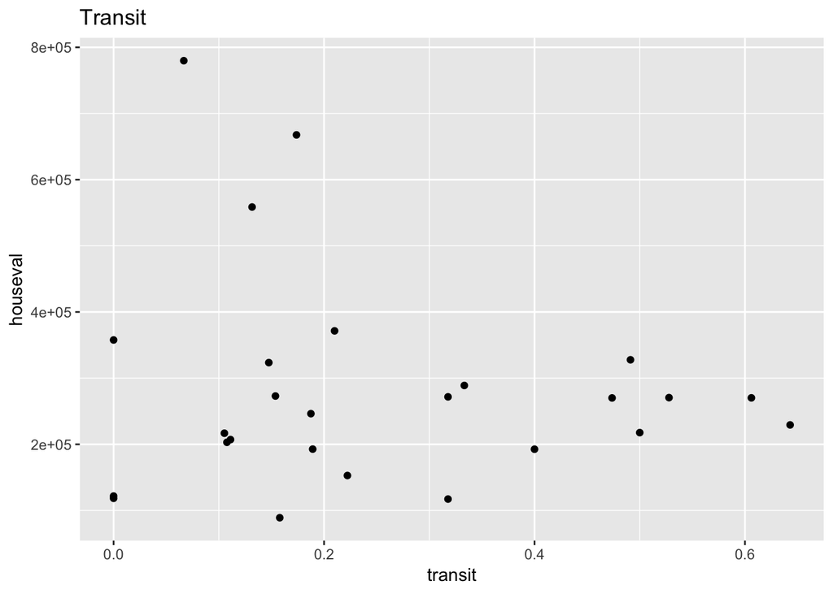

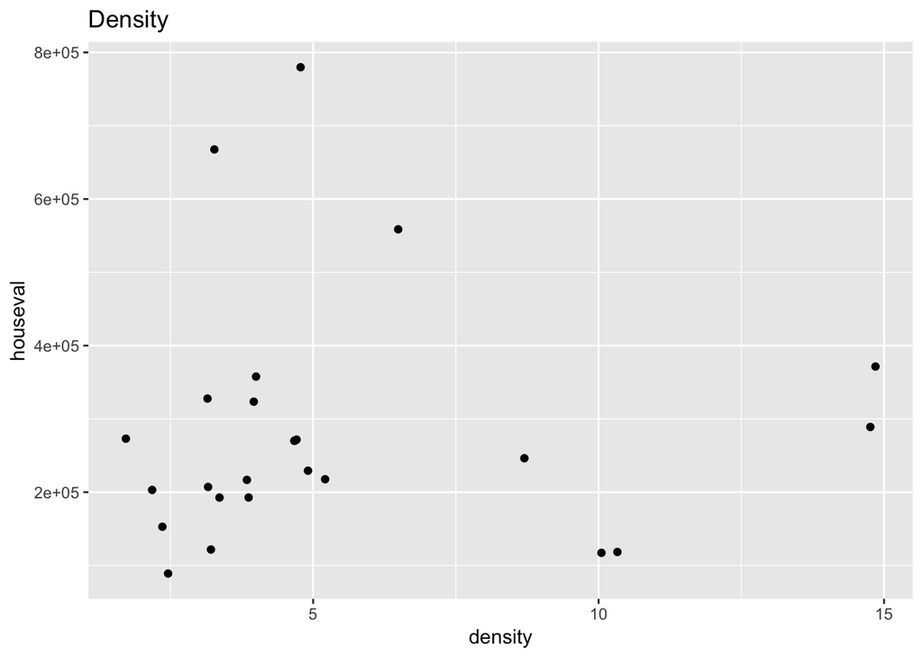

```r
huxreg(
 lm(houseval ~ transit * railtype + density + I(density^2),
data=Californiatod) %>% summary()
 )
```

|  | (1) |
| --- | --- |
| (Intercept) | 460167.738 ** |
|  | (125295.683) |
| transit | -488452.244 * |
|  | (179297.710) |
| railtypeLight rail | -294491.862 ** |
|  | (96497.627) |
| density | 16214.089 |
|  | (35885.168) |
| I(density^2) | -1225.750 |
|  | (2140.063) |
| transit:railtypeLight rail | 245732.471 |
|  | (463501.470) |
| N | 26 |
| R2 | 0.459 |
| *** p < 0.001; ** p < 0.01; * p < 0.05. |  |

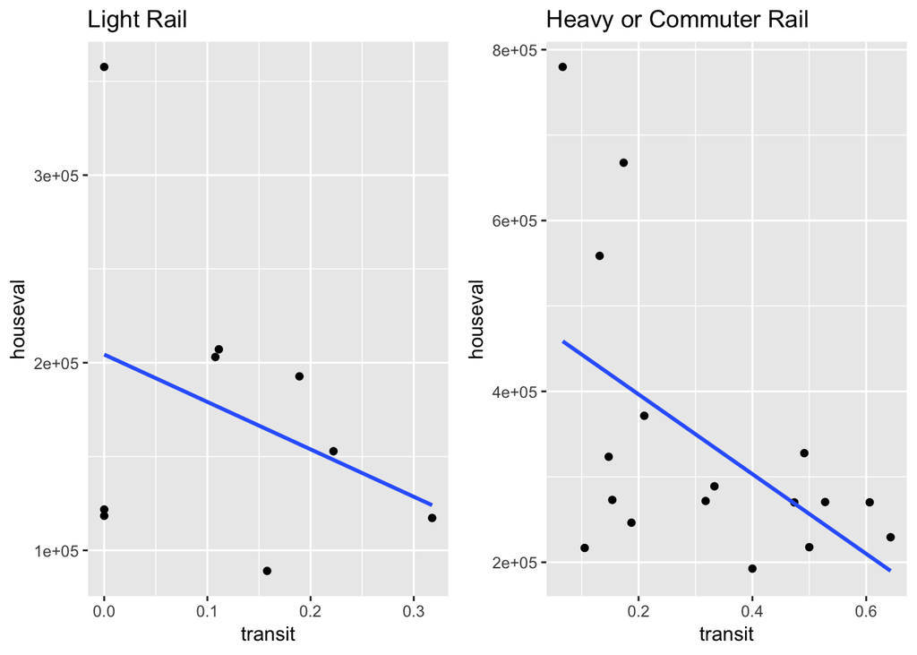

```r
CaliforniaTOD <- Californiatod %>%
  mutate(case_when(
             railtype == "Light rail" ~ 1,
             railtype == "Heavy or commuter rail" ~ 0))

CTOD_D <- rename(CaliforniaTOD, "dummy" = 7)

D1 <- CTOD_D %>%
  subset(dummy == 1)
D2 <- CTOD_D %>%
  subset(dummy == 0)

lm_D1 <- lm(houseval ~ transit, data = D1)
lm_D2 <- lm(houseval ~ transit, data = D2)

p1 <- ggplot(D1, aes(transit, houseval)) +
  geom_point() +
  geom_smooth(method = "lm", se = FALSE) +
  ggtitle("Light Rail")

p2 <- ggplot(D2, aes(transit, houseval)) +
  geom_point() +
  geom_smooth(method = "lm", se = FALSE) +
  ggtitle("Heavy or Commuter Rail")

Rmisc::multiplot(p1, p2, cols = 2)
```

Denisty has no effect on house value.